# Coronavirus US - USA Facts

There is clearly a data issue with cluster 32510. Clusters are examined at a variable number of cut points:

```
## .
##   1   2
## 841 149
```

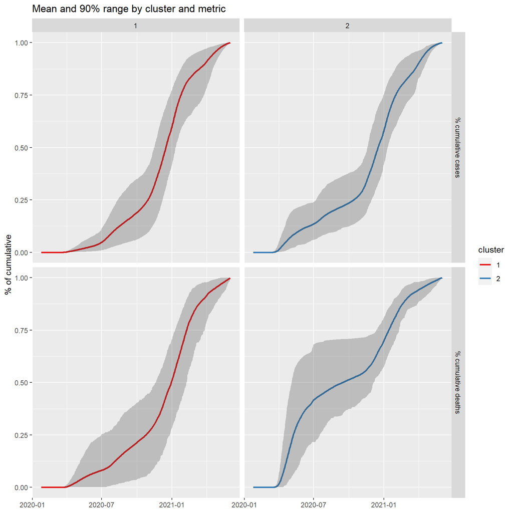

```
## .
##   1   2   3
## 773  68 149
```

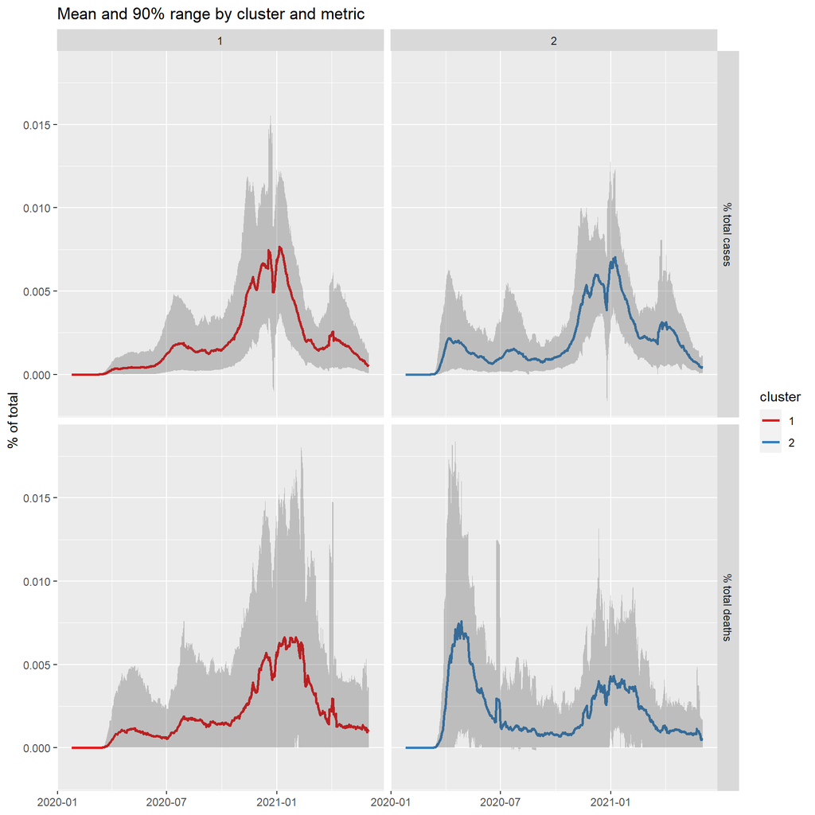

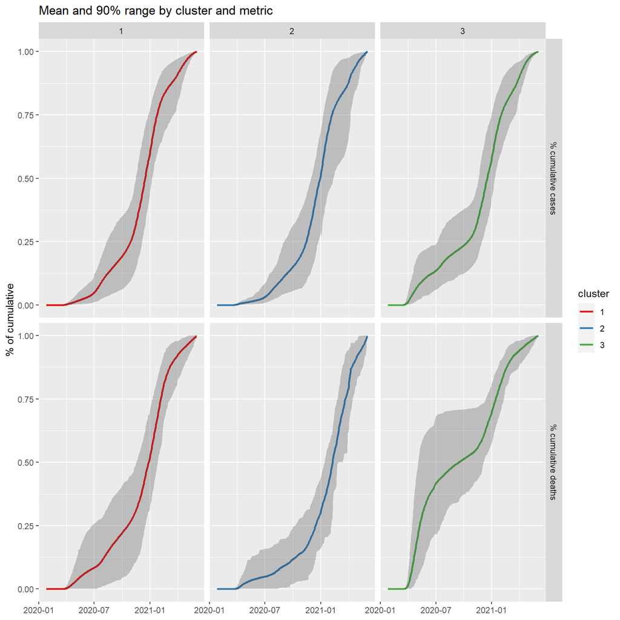

```
## .
##   1   2   3   4
## 498 275  68 149
```

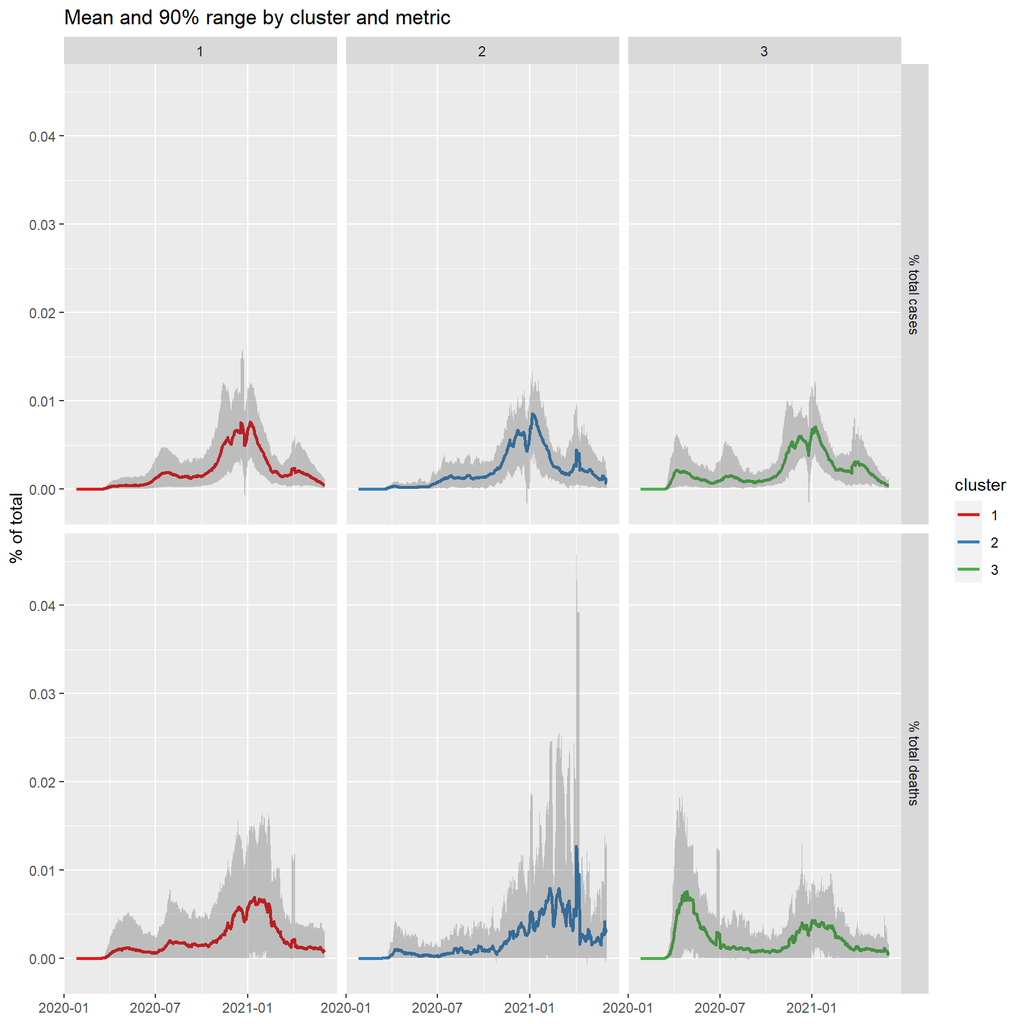

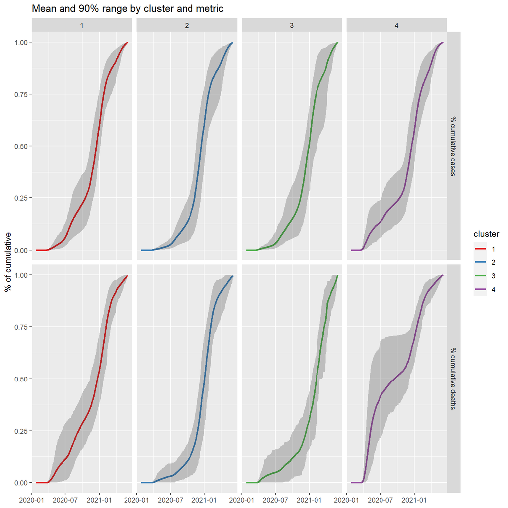

```
## .
##   1   2   3   4   5
## 498 275  68 114  35
```

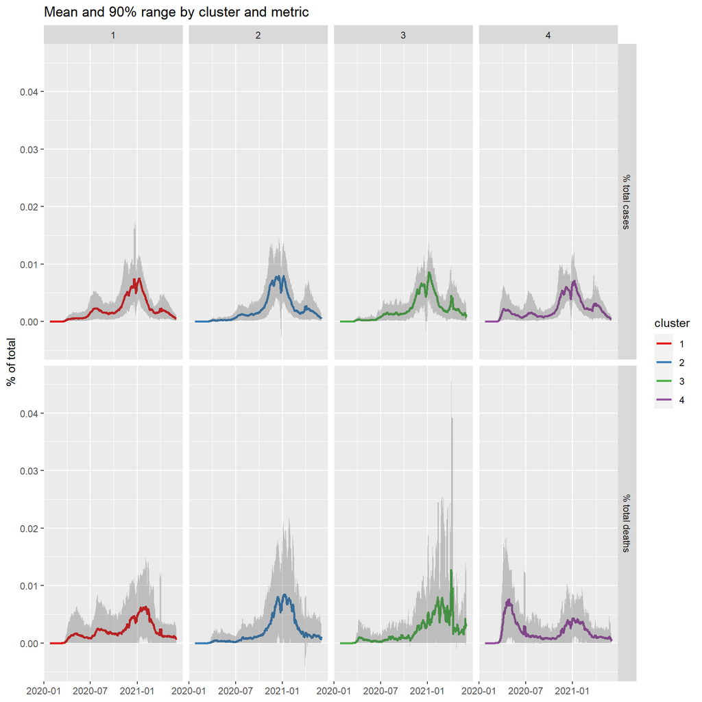

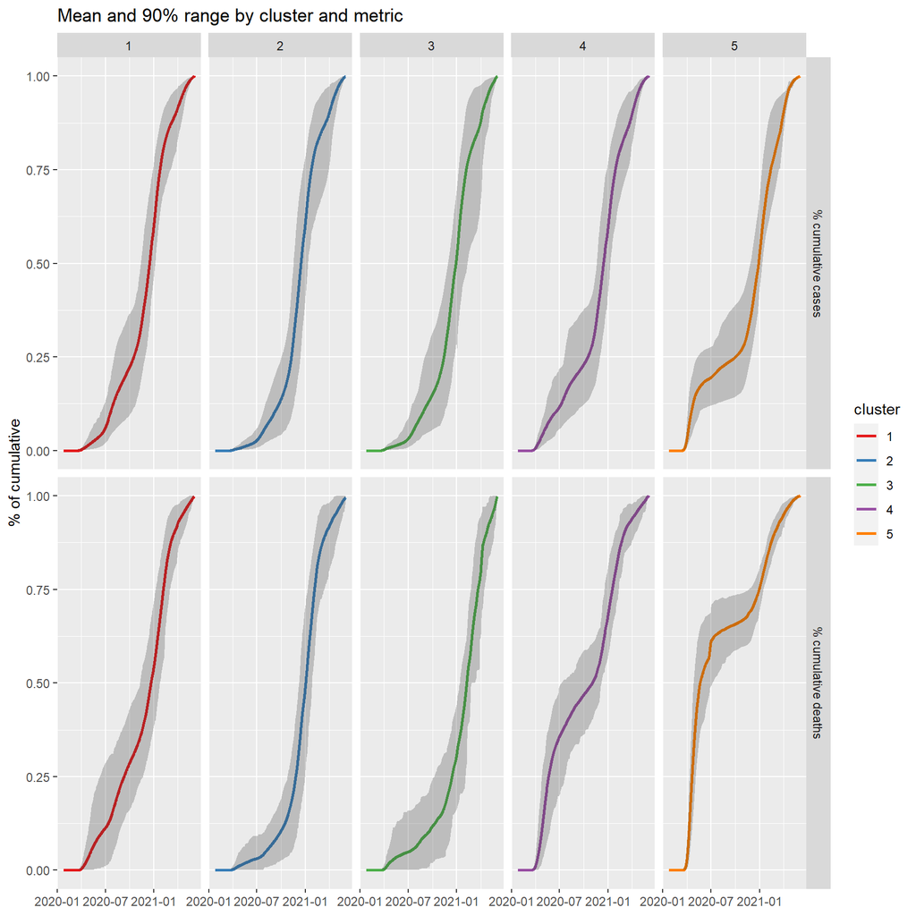

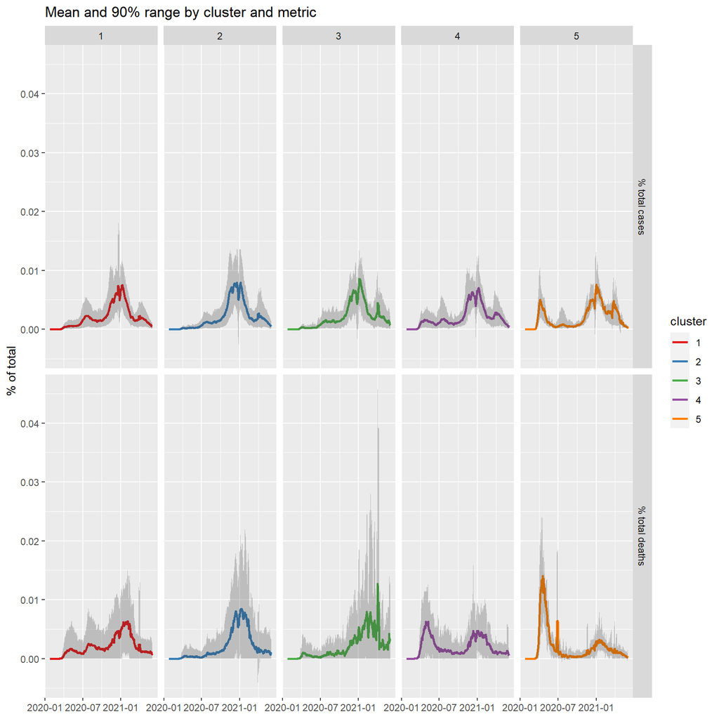

```r
plotHierarchical <- function(obj, k, df) {

    # FUNCtION ARGuMENTS:
    # obj: clustering object from hierarchical clustering
    # k: number of clusters to create
    # df: data frame with burden data

    # Counts by cluster
    ctCluster <- cutree(obj, k=k) %>%
        table() %>%
        print()

    # Make clustering data frame
    clData <- cutree(obj, k=k) %>%
        clustersToFrame(colNameName="countyFIPS") %>%
        joinFrames(df) %>%
        group_by(countyFIPS, name) %>%
        mutate(delta=ifelse(row_number()==1, pct, pct-lag(pct))) %>%
        ungroup() %>%
        group_by(cluster, date, name) %>%
        summarize(p05cum=quantile(pct, 0.05),
                  mucum=mean(pct),
                  p95cum=quantile(pct, 0.95),
                  p05delta=quantile(delta, 0.05),
                  mudelta=mean(delta),
                  p95delta=quantile(delta, 0.95),
                  .groups="drop"
                  )

    # Plot by cluster and metric
    p1 <- clData %>%
        ggplot(aes(x=date)) +
        geom_line(aes(color=cluster, y=mucum), lwd=1) +
        geom_ribbon(aes(ymin=p05cum, ymax=p95cum), alpha=0.25) +
        facet_grid(c("tcpm7"="% cumulative cases", "tdpm7"="% cumulative deaths")[name]~cluster) +
        scale_color_brewer(palette="Set1") +
        labs(x=NULL, y="% of cumulative", title="Mean and 90% range by cluster and metric")
    print(p1)

    # Plot incremental rather than cumulative
    p2 <- clData %>%
        ggplot(aes(x=date)) +
        geom_line(aes(color=cluster, y=mudelta), lwd=1) +
        geom_ribbon(aes(ymin=p05delta, ymax=p95delta), alpha=0.25) +
        facet_grid(c("tcpm7"="% total cases", "tdpm7"="% total deaths")[name]~cluster) +
        scale_color_brewer(palette="Set1") +
        labs(x=NULL, y="% of total", title="Mean and 90% range by cluster and metric")
    print(p2)

    # Return the clustering frame
    clData

}

plotList <- lapply(2:5, FUN=function(x) plotHierarchical(p2Complete, k=x, df=p2Data))
```

- The first split is between early (15%) and late (85%) burden
- The second and third splits, both applied to the ‘late’ cluster, merit further exploration
- The fourth split is of the early bucket, split in to early/late and mainly early

At a glance, with 5 clusters, there is a clear early cluster, a clear early/late cluster, and a group of three seemingly similar clusters (primarily late). Further exploration of these three clusters may be merited.